# Genome-wide methylation analysis report

# Genome-wide methylation analysis report

- study: Pleural cfDNAm analysis of horvath.platevariable
- author: Paul Yousefi
- date: 08 October, 2026

## Parameters

```
## $sig.threshold
## [1] 2.121143e-07
##
## $max.plots
## [1] 10
##
## $qq.inflation.method
## [1] "median"
##
## $practical.threshold
## [1] 8.594111e-12
```

## Sample characteristics

For continuous or ordinal variables, the “mean” column provides the mean and the “sd/%” column the standard deviation of the variable. For categorical variables, the “mean” column provides the number of samples with the given “value” and the “sd/%” column the percentage of samples with the given “value”.

| variable | value | mean | sd.. |
| --- | --- | --- | --- |
| horvath |  | 63.37898 | 18.3174 |
| plate |  | 2.319218 | 1.048991 |
| sv1 |  | 8.28183e-19 | 0.0571662 |
| sv2 |  | -9.382807e-19 | 0.0571662 |
| sv3 |  | 2.377873e-19 | 0.0571662 |
| sv4 |  | 3.282947e-18 | 0.0571662 |
| sv5 |  | 8.370672e-19 | 0.0571662 |
| sv6 |  | -1.280206e-18 | 0.0571662 |
| sv7 |  | -2.035037e-18 | 0.0571662 |
| sv8 |  | -1.077137e-17 | 0.0571662 |
| sv9 |  | -1.267956e-18 | 0.0571662 |
| sv10 |  | 8.216067e-17 | 0.0571662 |

## Covariate associations

### Covariate plate

statistics

| var1 | var2 | F | p-value | R | p-value |
| --- | --- | --- | --- | --- | --- |
| horvath | plate | 0.0168517 | 0.8967992 | -0.0130034 | 0.8204868 |

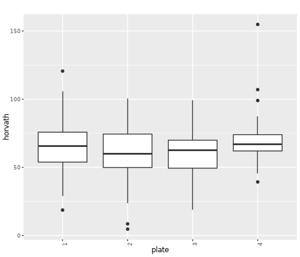

### Covariate sv1

statistics

| var1 | var2 | F | p-value | R | p-value |
| --- | --- | --- | --- | --- | --- |
| horvath | sv1 | 3.214661 | 0.0739721 | 0.1385937 | 0.0151496 |

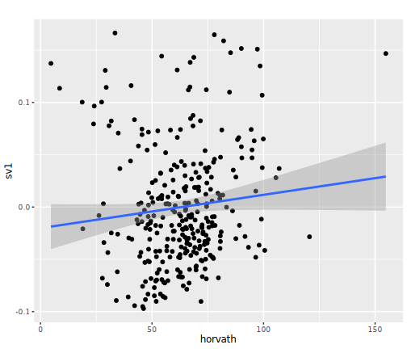

### Covariate sv2

statistics

| var1 | var2 | F | p-value | R | p-value |
| --- | --- | --- | --- | --- | --- |
| horvath | sv2 | 0.6141596 | 0.4338341 | -0.0892294 | 0.1186829 |

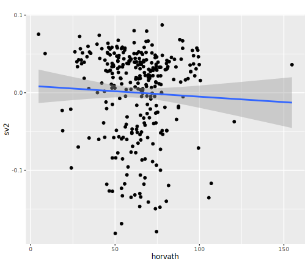

### Covariate sv3

statistics

| var1 | var2 | F | p-value | R | p-value |
| --- | --- | --- | --- | --- | --- |
| horvath | sv3 | 2.127295 | 0.1457249 | 0.1076519 | 0.0595945 |

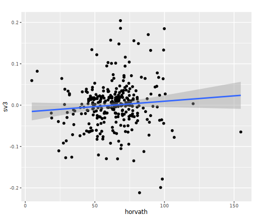

### Covariate sv4

statistics

| var1 | var2 | F | p-value | R | p-value |
| --- | --- | --- | --- | --- | --- |
| horvath | sv4 | 0.0315117 | 0.8592214 | -0.0277126 | 0.6284314 |

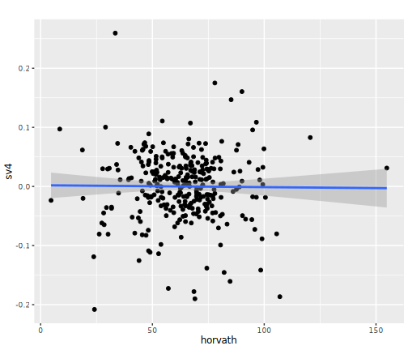

### Covariate sv5

statistics

| var1 | var2 | F | p-value | R | p-value |
| --- | --- | --- | --- | --- | --- |
| horvath | sv5 | 18.94219 | 1.84e-05 | -0.3224499 | 0 |

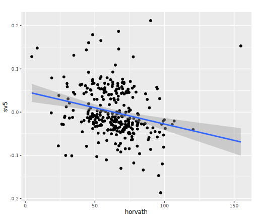

### Covariate sv6

statistics

| var1 | var2 | F | p-value | R | p-value |
| --- | --- | --- | --- | --- | --- |
| horvath | sv6 | 21.33623 | 5.7e-06 | 0.1973201 | 0.000518 |

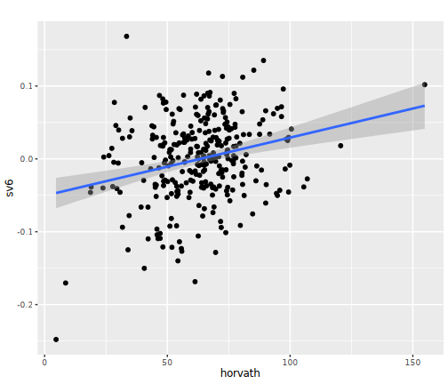

### Covariate sv7

statistics

[output not shown]

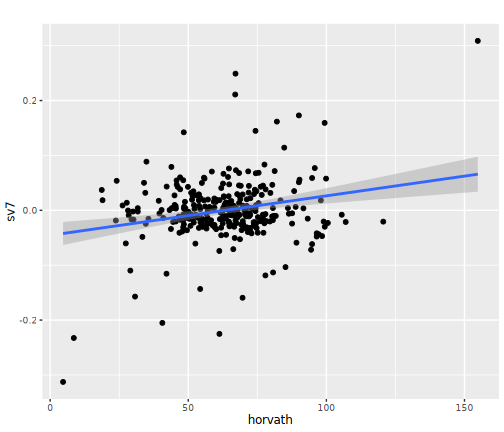

### Covariate sv8

statistics

| var1 | var2 | F | p-value | R | p-value |
| --- | --- | --- | --- | --- | --- |
| horvath | sv8 | 0.9403509 | 0.332956 | 0.0611203 | 0.2855521 |

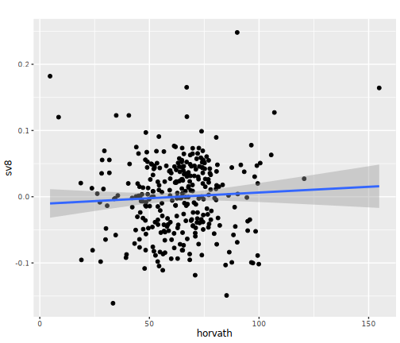

### Covariate sv9

statistics

| var1 | var2 | F | p-value | R | p-value |
| --- | --- | --- | --- | --- | --- |
| horvath | sv9 | 0.1008213 | 0.7510635 | 0.0269764 | 0.6375858 |

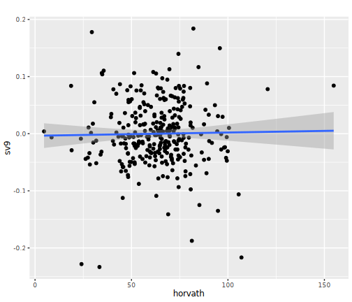

### Covariate sv10

statistics

| var1 | var2 | F | p-value | R | p-value |
| --- | --- | --- | --- | --- | --- |
| horvath | sv10 | 6.847754 | 0.0093175 | -0.1918091 | 0.0007438 |

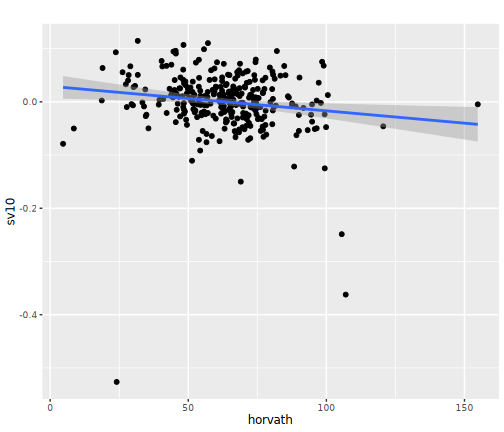

## QQ plots

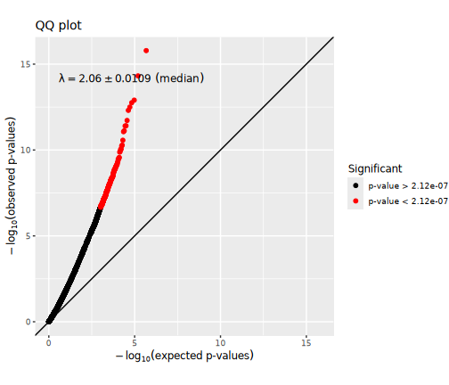

## Manhattan plots

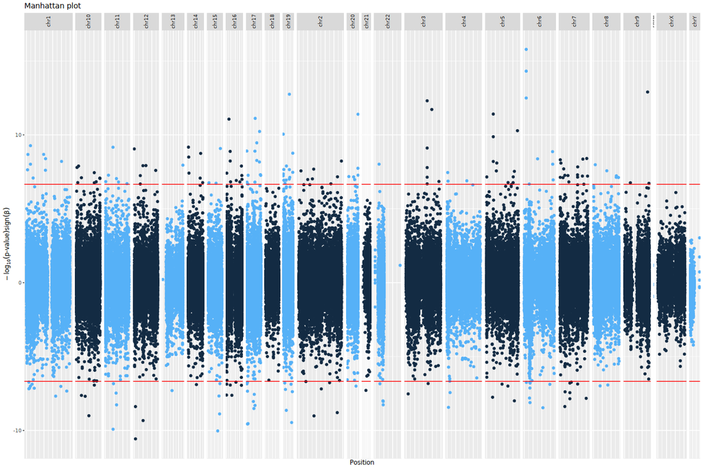

## Significant CpG sites

There were 226 CpG sites with association p-values < 2.1211427 × 10<sup>-7</sup>. These are listed in the file associations.csv.

Below are the 10 CpG sites with association p-values < 8.5941109 × 10<sup>-12</sup> in the regression model.

|  | chromosome | position | estimate | p.value | p.adjust |
| --- | --- | --- | --- | --- | --- |
| cg09157076 | chr6 | 11044880 | 0.0030137 | 0 | 0.0e+00 |
| cg11071401 | chr17 | 48637194 | 0.0023060 | 0 | 1.8e-06 |
| cg24724428 | chr6 | 11044888 | 0.0036541 | 0 | 0.0e+00 |
| cg17280346 | chr3 | 147126703 | 0.0036863 | 0 | 5.0e-07 |
| cg10943458 | chr3 | 120627085 | 0.0029309 | 0 | 1.0e-07 |
| cg21572722 | chr6 | 11044894 | 0.0021116 | 0 | 1.0e-07 |
| cg17110586 | chr19 | 36454623 | 0.0033019 | 0 | 0.0e+00 |
| cg21888602 | chr9 | 131450696 | 0.0028834 | 0 | 0.0e+00 |
| cg14847379 | chr20 | 62810902 | 0.0020509 | 0 | 9.0e-07 |
| cg26789779 | chr5 | 37839943 | 0.0013162 | 0 | 9.0e-07 |

Plots of these sites follow, one for each covariate set. “p[lm]” denotes the p-value obtained using a linear model and “p[beta]” the p-value obtained using beta regression.

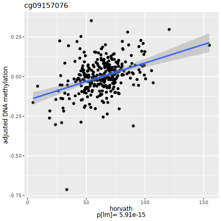

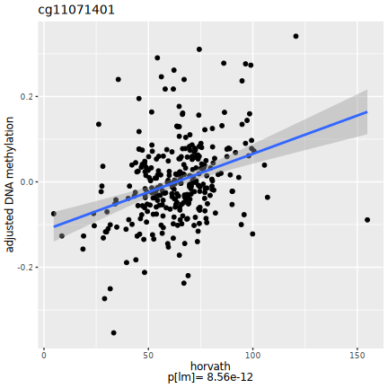

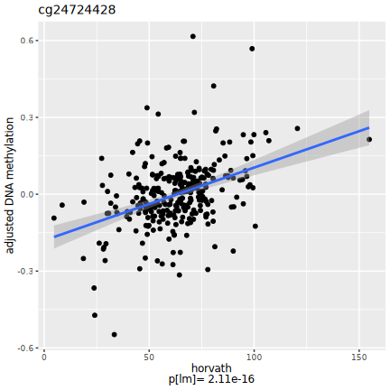

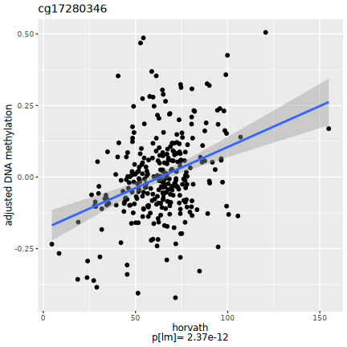

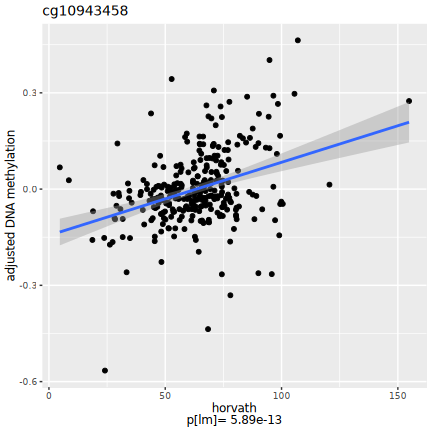

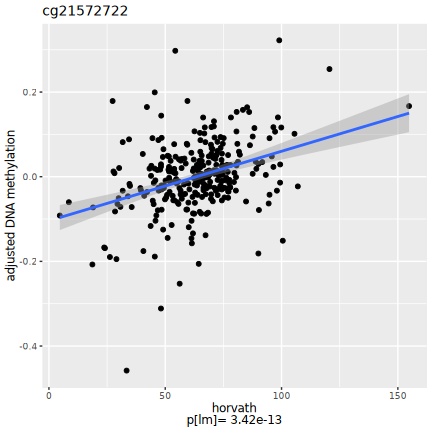

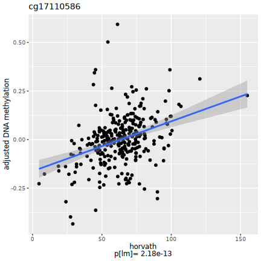

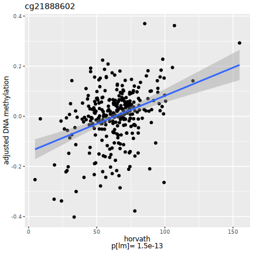

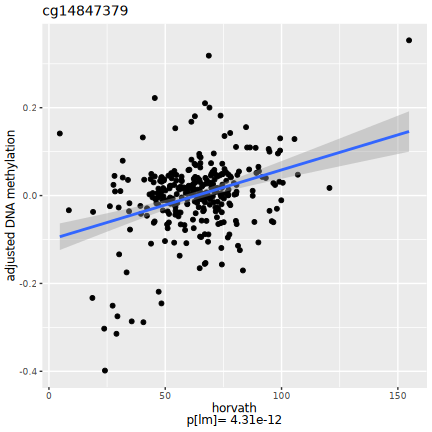

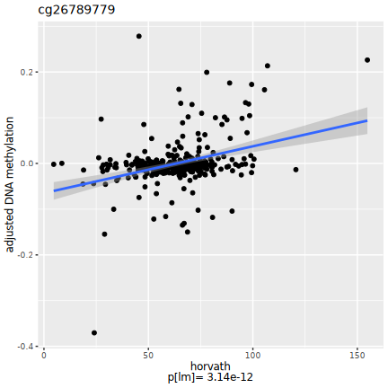

## Selected CpG sites

Number of CpG sites selected: 0.

| chromosome | position | estimate | p.value | p.adjust |
| --- | --- | --- | --- | --- |